# Assignment02-Data Viz and Wrangling

## Create new variables.

```r
library(tidyverse)
dat[, obesity_level := cut(bmi2,
                           breaks = c(0, 14, 22, 24, Inf),
                           include.lowest = TRUE,
                           labels = c("underweight", "normal", "overweight", "obese"))]

dat[, table(obesity_level)]
```

```
## obesity_level
## underweight      normal  overweight       obese
##          35         975          87         103
```

```r
dat %>%
  group_by(obesity_level) %>%
  summarise(n(),
            min = min(bmi2),
            max = max(bmi2)
  )
```

```
## # A tibble: 4 x 4
##   obesity_level `n()`   min   max
##   <fct>         <int> <dbl> <dbl>
## 1 underweight      35  11.3  14.0
## 2 normal          975  14.0  22.0
## 3 overweight       87  22.0  24.0
## 4 obese           103  24.0  41.3
```

Then we generate variable “smoke_gas_exposure”. “1” stands for non-second-hand-smoker and no gas-stove; “2” stands for second-hand-smoker and no gas-stove; “3” stands for non-second-hand-smoker and gas stove; “4” stands for second-hand-smoker and gas stove.

```r
dat[, smoke_gas_exposure := as.numeric(interaction(smoke2, gasstove2))]
dat[, .N, by = smoke_gas_exposure]
```

```
##    smoke_gas_exposure   N
## 1:                  1 224
## 2:                  2  37
## 3:                  3 786
## 4:                  4 153
```

## Summary Table

Last, we can make the following summary table to see how “Forced expiratory volume in 1 second (ml)” and asthma indicator is distributed by town, sex, obesity level, and “smoke_gas_exposure.”

```r
head(dat)
```

```
##    townname male hispanic      bmi asthma smoke gasstove      fev pm25_mass
## 1:   Alpine    0        0 15.33749      0     0        0 2529.276      8.74
## 2:   Alpine    0        1 15.93183      0    NA        0 1737.793      8.74
## 3:   Alpine    0        1 19.38649      0     1        0 2121.711      8.74
## 4:   Alpine    0        0 16.63283      0    NA       NA 2466.791      8.74
## 5:   Alpine    1        1 15.75758      0     0        0 2251.505      8.74
## 6:   Alpine    1        1 15.29189      0     1        0 2188.716      8.74
##          lon      lat     fev2     bmi2 asthma2 smoke2 gasstove2 obesity_level
## 1: -116.7664 32.83505 2529.276 15.33749       0      0         0        normal
## 2: -116.7664 32.83505 1737.793 15.93183       0      0         0        normal
## 3: -116.7664 32.83505 2121.711 19.38649       0      1         0        normal
## 4: -116.7664 32.83505 2466.791 16.63283       0      0         1        normal
## 5: -116.7664 32.83505 2251.505 15.75758       0      0         0        normal
## 6: -116.7664 32.83505 2188.716 15.29189       0      1         0        normal
##    smoke_gas_exposure
## 1:                  1
## 2:                  1
## 3:                  2
## 4:                  3
## 5:                  1
## 6:                  2
```

```r
#by town
dat %>%
  group_by(townname) %>%
  summarise(mean_fev    = mean(fev2),
            sd_fev      = sd(fev2),
            prop_asthma = length(which(asthma2 == 1)) / (1200-length(which(asthma2 == 1)))
  )
```

```
## # A tibble: 12 x 4
##    townname      mean_fev sd_fev prop_asthma
##    <chr>            <dbl>  <dbl>       <dbl>
##  1 Alpine           2087.   291.     0.00925
##  2 Atascadero       2076.   324.     0.0213
##  3 Lake Elsinore    2039.   304.     0.0101
##  4 Lake Gregory     2085.   320.     0.0127
##  5 Lancaster        2003.   317.     0.0135
##  6 Lompoc           2034.   351.     0.00925
##  7 Long Beach       1986.   319.     0.0110
##  8 Mira Loma        1985.   325.     0.0127
##  9 Riverside        1990.   278.     0.00925
## 10 San Dimas        2027.   319.     0.0144
## 11 Santa Maria      2026.   312.     0.0110
## 12 Upland           2024.   343.     0.0101
```

```r
#by sex
dat %>%
  group_by(male) %>%
  summarise(mean_fev    = mean(fev2),
            sd_fev      = sd(fev2),
            prop_asthma = length(which(asthma2 == 1)) / (1200-length(which(asthma2 == 1)))
  )
```

```
## # A tibble: 2 x 4
##    male mean_fev sd_fev prop_asthma
##   <int>    <dbl>  <dbl>       <dbl>
## 1     0    1959.   312.      0.0638
## 2     1    2104.   308.      0.0899
```

```r
#by obesity
dat %>%
  group_by(obesity_level) %>%
  summarise(mean_fev    = mean(fev2),
            sd_fev      = sd(fev2),
            prop_asthma = length(which(asthma2 == 1)) / (1200-length(which(asthma2 == 1)))
  )
```

```
## # A tibble: 4 x 4
##   obesity_level mean_fev sd_fev prop_asthma
##   <fct>            <dbl>  <dbl>       <dbl>
## 1 underweight      1698.   303.     0.00251
## 2 normal           2000.   295.     0.125
## 3 overweight       2224.   317.     0.0118
## 4 obese            2266.   325.     0.0178
```

```r
#by town
dat %>%
  group_by(smoke_gas_exposure) %>%
  summarise(mean_fev    = mean(fev2),
            sd_fev      = sd(fev2),
            prop_asthma = length(which(asthma2 == 1)) / (1200-length(which(asthma2 == 1)))
  )
```

```
## # A tibble: 4 x 4
##   smoke_gas_exposure mean_fev sd_fev prop_asthma
##                <dbl>    <dbl>  <dbl>       <dbl>
## 1                  1    2054.   327.     0.0274
## 2                  2    2057.   292.     0.00503
## 3                  3    2023.   320.     0.105
## 4                  4    2024.   302.     0.0161
```

# Exploratory Data Analysis

## Basic plots of main variables

1. Scatter plots with regression lines of BMI vs FEV by town.

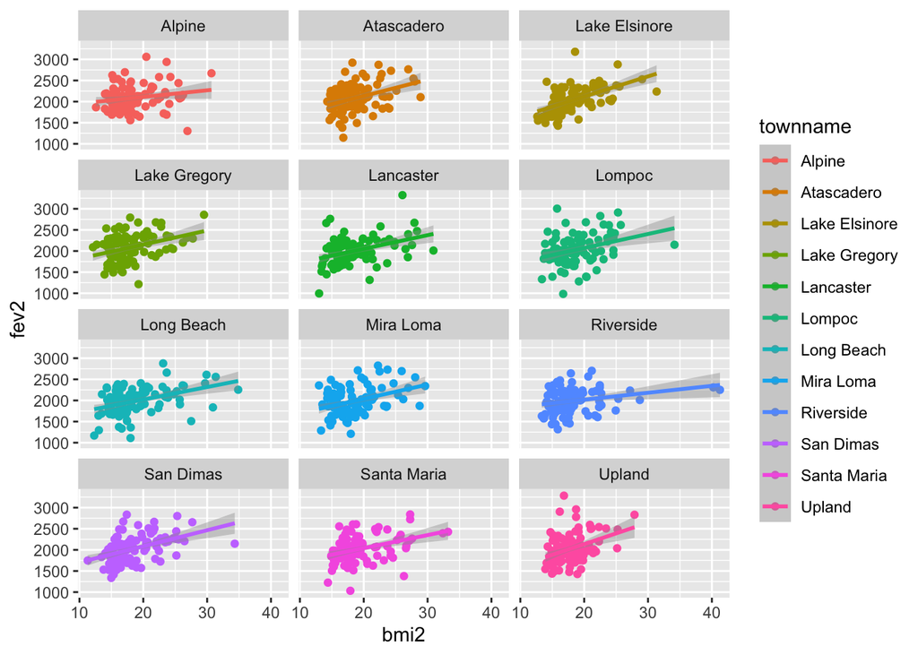

```r
dat %>%
  ggplot(mapping = aes(x=bmi2, y=fev2, color=townname))+
  geom_point()+
  stat_smooth(method=lm)+
  facet_wrap(~townname, nrow=4) #generate individual plot instead one
```

2. Histograms of FEV by Obesity_level and FEV by Smoke/Gas Exposure

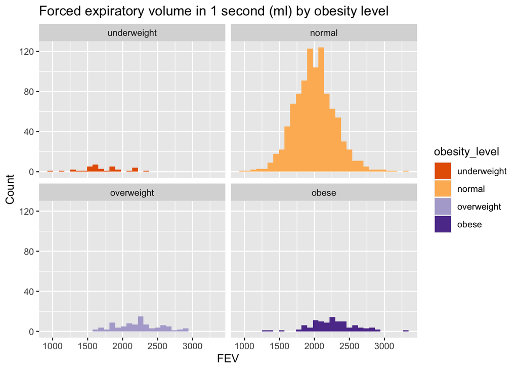

```r
dat %>%
  ggplot()+
  geom_histogram(mapping = aes(x=fev2, fill=obesity_level))+
  facet_wrap(~obesity_level, nrow=2)+
  scale_fill_brewer(palette = "PuOr")+
  labs(titles="Forced expiratory volume in 1 second (ml) by obesity level", x="FEV", y="Count")+
  theme_grey()
```

From the histograms above, we can see that most people have normal BMI(obesity_level). Within the normal group, FEV is normally distributed.

3. Barchart of BMI level by smoke/gas exposure.

```r
table(dat$obesity_level,dat$smoke_gas_exposure)
```

```
##
##                 1   2   3   4
##   underweight   5   0  26   4
##   normal      186  31 637 121
##   overweight   13   1  60  13
##   obese        20   5  63  15
```

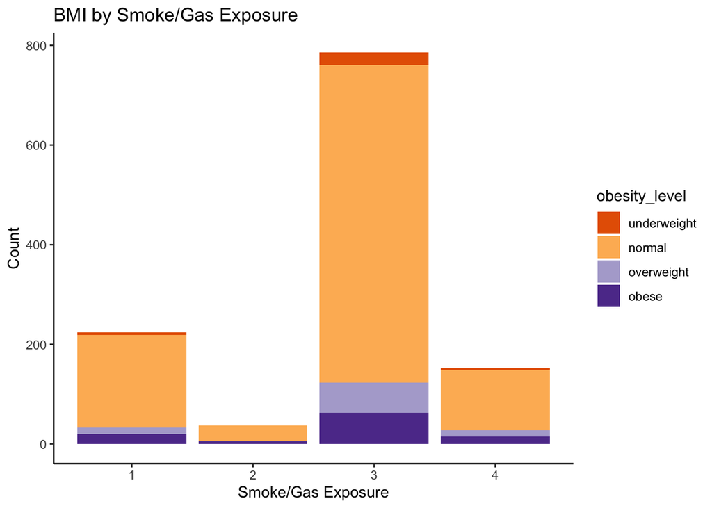

```r
dat %>%
  ggplot()+
  geom_bar(mapping = aes(x=smoke_gas_exposure, fill=obesity_level))+
  scale_fill_brewer(palette = "PuOr")+
  labs(titles="BMI by Smoke/Gas Exposure", x="Smoke/Gas Exposure", y="Count")+
  theme_classic()
```

4. Statistical summary graphs of FEV by BMI and FEV by smoke/gas exposure category.

```r
#install.packages("Hmisc")
library(Hmisc)
```

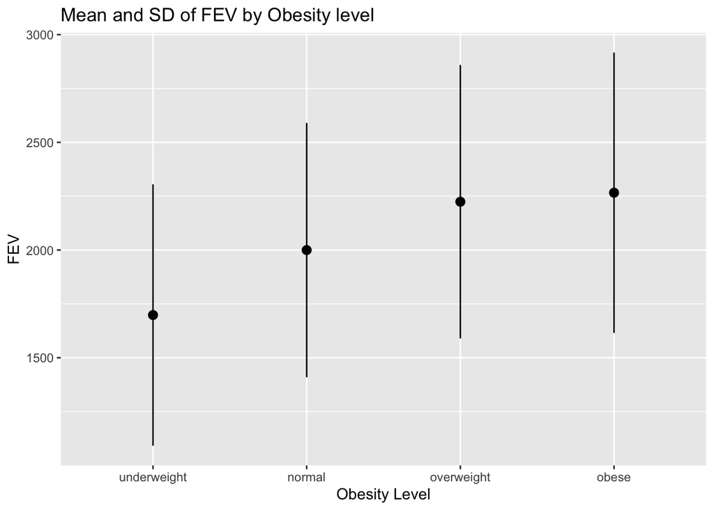

```r
dat %>%
  ggplot(mapping = aes(x = obesity_level, y = fev2)) +
  stat_summary(fun.data="mean_sdl")+
  labs(titles="Mean and SD of FEV by Obesity level", x="Obesity Level", y="FEV")
```

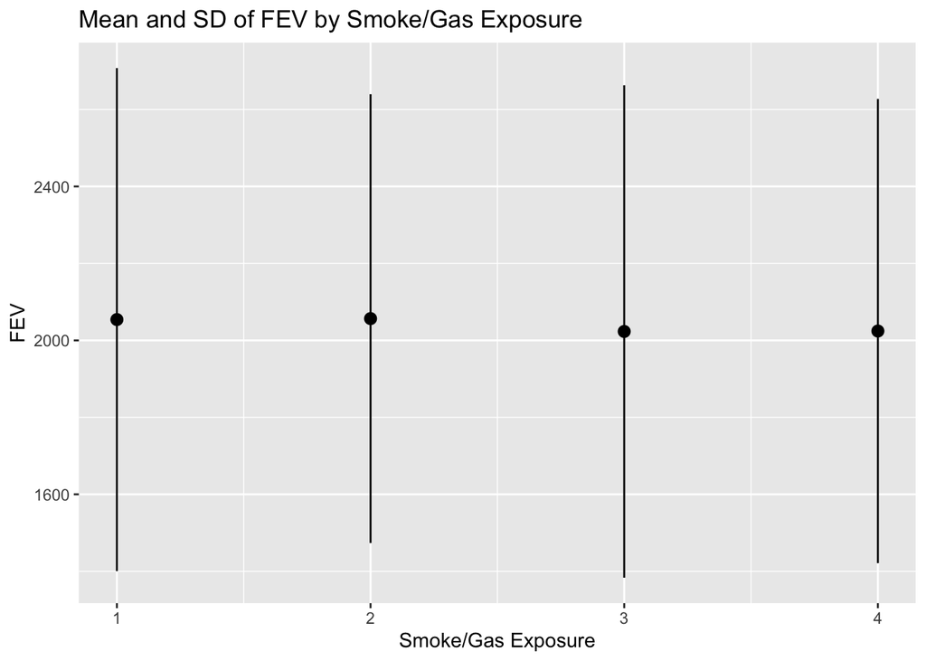

```r
dat %>%
  ggplot(mapping = aes(x = smoke_gas_exposure, y = fev2)) +
  stat_summary(fun.data="mean_sdl")+
  labs(titles="Mean and SD of FEV by Smoke/Gas Exposure", x="Smoke/Gas Exposure", y="FEV")
```

From the first statistic summary graph, we can see that the mean of FEV gets larger when obesity level increase. However, the standard deviations of FEV between each groups are quite similar. From the second graph, we can see that the means and SD of FEV between each 4 Smoke/Gas exposure groups are almost the same.

5. A leaflet map showing the concentrations of PM2.5 mass in each of the CHS communities.

```r
library(leaflet)

leaflet(dat) %>%
  addProviderTiles('OpenStreetMap') %>%
  addCircles(lat=~lat, lng=~lon, color="blue",opacity=1,
             fillOpacity=1, radius=~(pm25_mass*300))
```

[interactive chart not shown]

From the leaflet plot above, we can see that town around Los Angeles has higher PM2.5 Mass compared to those not located around LA. Especially, towns in the East side of LA has even higher PM2.5 Mass than other towns.

6. Association between FEV and PM2.5 Mass.

Since we only have town-level PM2.5 Mass. Thus we can calculate town-level FEV (mean FEV by town), then draw regression line to see if these two variable are related.

```r
dat[,fev_town :=mean(fev2),by=townname]
head(dat)
```

```
##    townname male hispanic      bmi asthma smoke gasstove      fev pm25_mass
## 1:   Alpine    0        0 15.33749      0     0        0 2529.276      8.74
## 2:   Alpine    0        1 15.93183      0    NA        0 1737.793      8.74
## 3:   Alpine    0        1 19.38649      0     1        0 2121.711      8.74
## 4:   Alpine    0        0 16.63283      0    NA       NA 2466.791      8.74
## 5:   Alpine    1        1 15.75758      0     0        0 2251.505      8.74
## 6:   Alpine    1        1 15.29189      0     1        0 2188.716      8.74
##          lon      lat     fev2     bmi2 asthma2 smoke2 gasstove2 obesity_level
## 1: -116.7664 32.83505 2529.276 15.33749       0      0         0        normal
## 2: -116.7664 32.83505 1737.793 15.93183       0      0         0        normal
## 3: -116.7664 32.83505 2121.711 19.38649       0      1         0        normal
## 4: -116.7664 32.83505 2466.791 16.63283       0      0         1        normal
## 5: -116.7664 32.83505 2251.505 15.75758       0      0         0        normal
## 6: -116.7664 32.83505 2188.716 15.29189       0      1         0        normal
##    smoke_gas_exposure fev_town
## 1:                  1 2087.101
## 2:                  1 2087.101
## 3:                  2 2087.101
## 4:                  3 2087.101
## 5:                  1 2087.101
## 6:                  2 2087.101
```

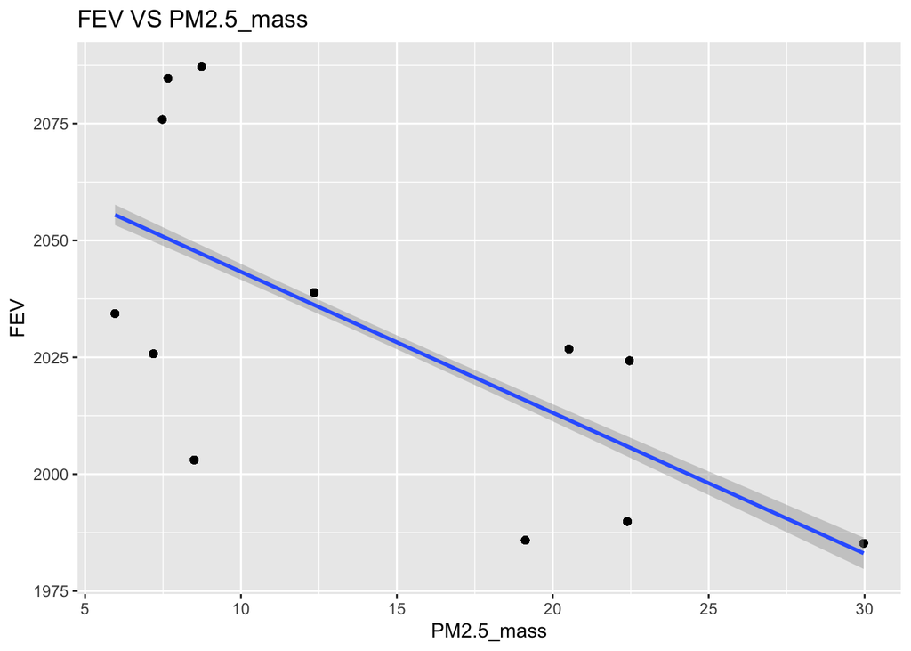

```r
dat %>%
  ggplot(mapping = aes(x=pm25_mass, y=fev_town))+
  geom_point()+
  stat_smooth(method=lm)+
  labs(titles="FEV VS PM2.5_mass", x="PM2.5_mass", y="FEV")
```

From the scatter plot above, we can see that FEV is negatively associated with PM2.5 mass. In other words, as PM2.5 mass increase, FEV decrease.